# Project: Investigate Gapminder Dataset (Education)

- Introduction
- Data Wrangling
- Exploratory Data Analysis
- Conclusions

## Introduction

This notenbook shows an investigation of the following Datasets, which have been imported from Gapminder:

- Average Score in the international TIMSS test for children in the 4th Grade
- Mean Years at School
- Income per person

>

```python
import pandas as pd
import numpy as py
import os
import matplotlib.pyplot as plt
import seaborn as sb
% matplotlib inline
```

```
UsageError: Line magic function `%` not found.
```

```python
os.getcwd()
```

```
'C:\\Users\\alaa.alsaiery\\Desktop\\Alaa\\Udacity\\Proj 2\\investigate-a-dataset-template.ipynb'
```

## Data Wrangling

### General Properties

```python
#Reading files
df_lifeex = pd.read_csv('life_expectancy_years.csv')
df_income = pd.read_csv('income_per_person.csv')
df_eyears = pd.read_csv('years_in_school_men_35_to_44_years.csv')
df_eachiv = pd.read_csv('math_achievement_4th_grade.csv')
df_literacy = pd.read_csv('literacy_rate_youth.csv')
```

```python
#Exploring the datasets
df_lifeex.head()
```

|  | country | 1800 | 1801 | 1802 | 1803 | 1804 | 1805 | 1806 | 1807 | 1808 | ... | 2009 | 2010 | 2011 | 2012 | 2013 | 2014 | 2015 | 2016 | 2017 | 2018 |
| --- | --- | --- | --- | --- | --- | --- | --- | --- | --- | --- | --- | --- | --- | --- | --- | --- | --- | --- | --- | --- | --- |
| 0 | Afghanistan | 28.2 | 28.2 | 28.2 | 28.2 | 28.2 | 28.2 | 28.1 | 28.1 | 28.1 | ... | 55.7 | 56.2 | 56.7 | 57.2 | 57.7 | 57.8 | 57.9 | 58.0 | 58.4 | 58.7 |
| 1 | Albania | 35.4 | 35.4 | 35.4 | 35.4 | 35.4 | 35.4 | 35.4 | 35.4 | 35.4 | ... | 75.9 | 76.3 | 76.7 | 77.0 | 77.2 | 77.4 | 77.6 | 77.7 | 77.9 | 78.0 |
| 2 | Algeria | 28.8 | 28.8 | 28.8 | 28.8 | 28.8 | 28.8 | 28.8 | 28.8 | 28.8 | ... | 76.3 | 76.5 | 76.7 | 76.8 | 77.0 | 77.1 | 77.3 | 77.4 | 77.6 | 77.9 |
| 3 | Andorra | NaN | NaN | NaN | NaN | NaN | NaN | NaN | NaN | NaN | ... | 82.7 | 82.7 | 82.6 | 82.6 | 82.6 | 82.6 | 82.5 | 82.5 | NaN | NaN |
| 4 | Angola | 27.0 | 27.0 | 27.0 | 27.0 | 27.0 | 27.0 | 27.0 | 27.0 | 27.0 | ... | 59.3 | 60.1 | 60.9 | 61.7 | 62.5 | 63.3 | 64.0 | 64.7 | 64.9 | 65.2 |

5 rows × 220 columns

## Unpivoting tables

```python
#unpivoting datasets
def my_function(df,temp):
    col=df.columns.tolist()
    col.pop(0)
    df_lx=pd.melt(df, id_vars =['country'], value_vars =col)
    df_lx.rename(columns = {'variable':'Year','value':temp}, inplace = True)
    return df_lx

df_m=my_function(df_eachiv,'Math Achievement')
df_le=my_function(df_lifeex,'Life Expectancy')
df_y=my_function(df_eyears,'Year in school')
df_l=my_function(df_literacy,'Literacy_Rate')
df_i=my_function(df_income,'Income')
df_l.head()
```

|  | country | Year | Literacy_Rate |
| --- | --- | --- | --- |
| 0 | Afghanistan | 1975 | NaN |
| 1 | Albania | 1975 | NaN |
| 2 | Algeria | 1975 | NaN |
| 3 | Angola | 1975 | NaN |
| 4 | Argentina | 1975 | NaN |

### Appending Datasets

```python
df = pd.merge(df_m, df_le,  how='outer', left_on=['country','Year'], right_on = ['country','Year'])
```

```python
df = pd.merge(df, df_y,  how='outer', left_on=['country','Year'], right_on = ['country','Year'])
```

```python
df = pd.merge(df, df_l,  how='outer', left_on=['country','Year'], right_on = ['country','Year'])
```

```python
df = pd.merge(df, df_i,  how='outer', left_on=['country','Year'], right_on = ['country','Year'])
```

```python
df.head()
```

|  | country | Year | Math Achievement | Life Expectancy | Year in school | Literacy_Rate | Income |
| --- | --- | --- | --- | --- | --- | --- | --- |
| 0 | Algeria | 1995 | NaN | 72.3 | 3.77 | NaN | 9300 |
| 1 | Armenia | 1995 | NaN | 69.3 | 10.10 | NaN | 2170 |
| 2 | Australia | 1995 | 495.0 | 78.3 | 11.60 | NaN | 30400 |
| 3 | Austria | 1995 | 531.0 | 76.7 | 10.80 | NaN | 33700 |
| 4 | Canada | 1995 | 514.0 | 78.0 | 13.40 | NaN | 32200 |

```python
#counting missing values
df.isnull().sum()
```

```
country                 0
Year                    0
Math Achievement    46444
Life Expectancy      6076
Year in school      37911
Literacy_Rate       45961
Income                  0
dtype: int64
```

## Exploratory Data Analysis

Now that we've trimmed and cleaned our data, we're ready to move on to exploration. The following code cells will focus on answering research question 1.

### Research Question 1. How GDP per capita varies among countries? and How GDP per capita is correlated with Years in school?

The following shows the steps to be followed in order to answer the question:

> **GDP per capita dataset**:

> **1**:To choose the most recent year in the data (which is 2019)

> **2**:To plot a histogram, which will make it easier to visualize the spread of our data.

> **3**:To identify countries with the highest and lowest GDP, using the .max() and .min() functions.

> **Years in school dataset**:

> **1**:The year which have data on both (GDP per capit and Years in school) with the least number of missing values is 2015. So we will select the data in year 2015 to do our analysis.

> **2**:To remove all missing values, in order to calculate the correlation.

> **4**:To calculate and plot the correlation between Years in school and GDP per capita variables. The correlation coeffieint is 0.7 which indicates a strong relationsip. The plot also shows an uphill (positive) linear relationship.

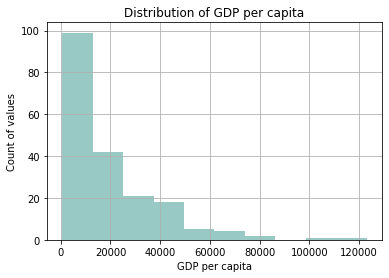

```python
#selecting year 2019
df_19=df[df['Year']=='2019']

# the histogram of the data
x= plt.hist(df_19['Income'],facecolor='#76b7b2', alpha=0.75)

#Add title, and x/y labels
plt.xlabel('GDP per capita')
plt.ylabel('Count of values')
plt.title('Distribution of GDP per capita')
plt.grid(True)

plt.show()
```

```python
#country with highest GDP per capita
x=df_19[df_19['Income']==df_19.Income.max()].country
xn=df_19['Income'].max()

#country with lowest GDP per capita
m=df_19[df_19['Income']==df_19.Income.min()].country
mn=df_19['Income'].min()


xn
```

```
123000
```

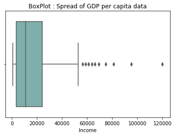

```python
#taking data of 2015 only
df_15=df[df['Year']=='2015']

#counting missing values
df_15.isnull().sum()

#removing nan
df_15.dropna(subset=['Year in school'])

#defining outliers
x=sb.boxplot(x=df_15['Income'],color='#76b7b2')
x.set_title('BoxPlot : Spread of GDP per capita data')

#remove outliers
df15= df_15[df_15['Income'] < 60000]
```

```python
# calculating the correl between Income and Life expectancy
df15.corr(method='pearson')
```

|  | Math Achievement | Life Expectancy | Year in school | Literacy_Rate | Income |
| --- | --- | --- | --- | --- | --- |
| Math Achievement | NaN | NaN | NaN | NaN | NaN |
| Life Expectancy | NaN | 1.000000 | 0.684001 | NaN | 0.734563 |
| Year in school | NaN | 0.684001 | 1.000000 | NaN | 0.695606 |
| Literacy_Rate | NaN | NaN | NaN | NaN | NaN |
| Income | NaN | 0.734563 | 0.695606 | NaN | 1.000000 |

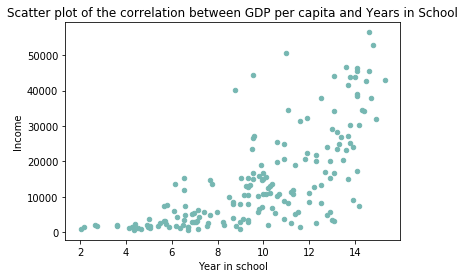

```python
#Plotting the corrleation btw Income and Year in school
df15.plot(x='Year in school',y='Income',kind='scatter',color='#76b7b2',title='Scatter plot of the correlation between GDP per capita and Years in School')
```

```python
df15.head()
```

|  | country | Year | Math Achievement | Life Expectancy | Year in school | Literacy_Rate | Income |
| --- | --- | --- | --- | --- | --- | --- | --- |
| 40205 | Afghanistan | 2015 | NaN | 57.9 | 3.59 | NaN | 1750 |
| 40206 | Albania | 2015 | NaN | 77.6 | 12.00 | NaN | 11000 |
| 40207 | Algeria | 2015 | NaN | 77.3 | 6.16 | NaN | 13700 |
| 40208 | Andorra | 2015 | NaN | 82.5 | 13.60 | NaN | 46600 |
| 40209 | Angola | 2015 | NaN | 64.0 | 7.13 | NaN | 6230 |

### Research Question 2 :

### How countries are performing in education based on the literacy rate indicator?

### Do top performing countries in education have high life expectancy?

## In the following code:

We will try to find out how countries are performing in education based on the literacy rate. The following shows the steps to be followed in order to answer the question:

> > **1**:To choose the most recent year in the data (which is 2011)

> > **2**:To remove all missing values from the dataset.

> > **3**:To change the data type from decimal to integer, since if we will draw the histogram for decimals it will show many different values and it will not be visually clear which rate has the highest count of values.

> > **4**:To draw the bar plot, which based on count of values shows the distribution of literacy rate over the different countries.

> > **5**:To identify countries with the highest and lowest literacy rates, based on the .max() and .min() functions.

> > **6**:To remove all missing values in rate literacy and life expectancy and calculate the correlations between the two variables using the corr(method='pearson').

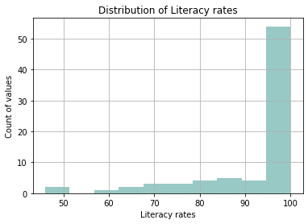

```python
#analyzing literacy rate
df_11=df[df['Year']=='2011']

#counting missing values
df_11.isnull().sum()

#removing nan
dfx=df_11.dropna(subset=['Literacy_Rate'])

#convert Literacy rate to int
dfx['Literacy_Rate']=dfx['Literacy_Rate'].astype(int)

#plotting literacy rate on a bar chart
#y=dfx['Literacy_Rate'].value_counts().plot(x='Literacy rate',kind='bar', figsize=(8,8),color='#76b7b2')
#y.set_title('Distribution of Literacy rates')

# the histogram of the data
y= plt.hist(dfx['Literacy_Rate'],facecolor='#76b7b2', alpha=0.75)

#Add title, and x/y labels
plt.xlabel('Literacy rates')
plt.ylabel('Count of values')
plt.title('Distribution of Literacy rates')
plt.grid(True)

plt.show()
```

```python
#Coutries with the highest Literacy Rate
x=dfx[dfx['Literacy_Rate']==dfx.Literacy_Rate.max()].country

#Countries with the lowest Literacy Rate
y=dfx[dfx['Literacy_Rate']==dfx.Literacy_Rate.min()].country
```

```python
#all data count na values
df.isnull().sum()

#removing nan for litracy rate
dfy=df.dropna(subset=['Literacy_Rate'])

dfy.isnull().sum()
```

```
country               0
Year                  0
Math Achievement    547
Life Expectancy       1
Year in school        1
Literacy_Rate         0
Income                0
dtype: int64
```

```python
#removing nan for litracy rate
dfy=dfy.dropna(subset=['Life Expectancy'])
dfy.isnull().sum()

#correl btw Life Expectancy and Literacy Rate
dfy.corr(method='pearson')
```

|  | Math Achievement | Life Expectancy | Year in school | Literacy_Rate | Income |
| --- | --- | --- | --- | --- | --- |
| Math Achievement | 1.000000 | -0.574149 | -0.130550 | -0.328697 | -0.830696 |
| Life Expectancy | -0.574149 | 1.000000 | 0.660880 | 0.724325 | 0.410492 |
| Year in school | -0.130550 | 0.660880 | 1.000000 | 0.768887 | 0.277970 |
| Literacy_Rate | -0.328697 | 0.724325 | 0.768887 | 1.000000 | 0.254619 |
| Income | -0.830696 | 0.410492 | 0.277970 | 0.254619 | 1.000000 |

## Limitations

> **1**: Data was not suffieicient to prove the findings, many missing data for many countries. For instance the life expectancy data is only available for 184 countries.

> **2**: There are no recent data, the recent numbers on life expectancy sts are on 2018

> **3**: All data were pivoted.

> **4**: Since there were a lot of missing data in some years or for some countries, it was difficult to find the correlation between two unrelated variables in the same year.

## Conclusions

### Key Findings:

> **2**: Qatar is the country which had the highest GDP per capita (with almost 123000) in the world for 2019, and Somalia had the lowest GDP per capita (with only 631).

> **3**: The data shows that there is a strong positive relationship between Years spent in education and GDP per capita.

> **4**: Cuba, Moldova and Poland are on eone of the countries in the world which have 100% rate of literacy, where Mali is one of the countries which have the lowest literacy rate (with 46% Literacy rate).

> **4**: The correlation coefficient shows a strong positive relation between Literacy rate, and Life expectancy.